# S8 : Predictive performance in Ecological Modelling

Marine Ecological Modelling  
Global Climate Change

#### S8 : Predictive performance in Ecological Modelling

author: Jorge Assis  
contact: jmassis@ualg.pt  
code: github.com/jorgeassis  
tweets: twitter.com/jorgemfassis  
journal: [medium.com/theMarineDataScientist](https://medium.com/themarinedatascientist)

##### Model evaluation [!]

```r
# always set a working directory
setwd(".")

# all packages needed and functions in external source file
source("sourceFunctions.R")
```

###### Model evaluation without cross-validation

Model evaluation computed only with the training dataset.

```r
presences <- read.csv("Data/dataBases/Paramuricea_clavata.csv",sep=";")
presences <- presences[,c("Lon","Lat")]

# load layers of sea surface temperatures
environmentalConditions <- load_layers(c("BO2_tempmin_bdmean","BO2_tempmax_bdmean"))

# crop layers to the European extent
europeanExtent <- extent(-15, 40, 25, 50)
environmentalConditions <- crop(environmentalConditions,europeanExtent)

# generate background information
background <- backgroundInformation(environmentalConditions,n=10000)

# extract environmental values and make a data.frame with PA information
modelData <- prepareModelData(presences,background,environmentalConditions)

# fit a Maxent model to the dataset
model <- train("Maxnet", modelData, folds = NULL )

# determine threshold dependent indices
getAccuracy(model)
```

```
##   threshold omission.rate sensitivity specificity prop.correct     Kappa
## 1       0.5     0.3349282   0.6650718      0.9753     0.968949 0.4526891
```

```r
# determine threshold dependent indices (low threshold retrieve high sensitivity)
getAccuracy(model,threshold = 0.1)
```

```
##   threshold omission.rate sensitivity specificity prop.correct     Kappa
## 1       0.1    0.05741627   0.9425837      0.8915    0.8925458 0.2374051
```

```r
# determine threshold dependent indices (high threshold retrieve low sensitivity)
getAccuracy(model,threshold = 0.9)
```

```
##   threshold omission.rate sensitivity specificity prop.correct Kappa
## 1       0.9             1           0           1    0.9795279     0
```

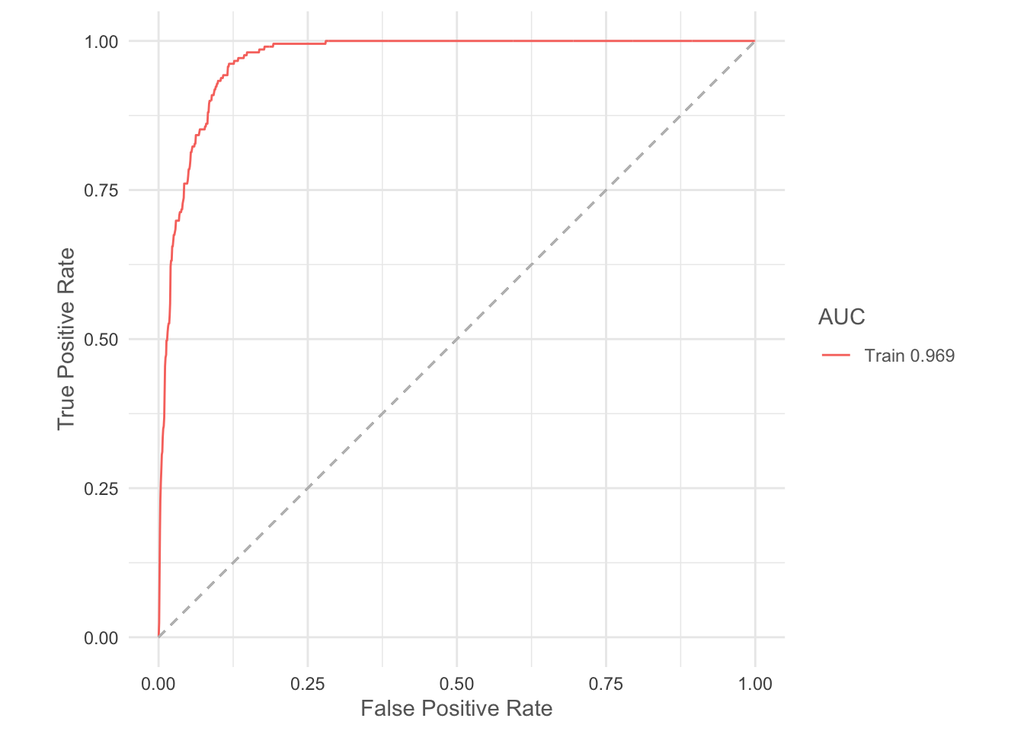

```r
# plot the threshold-independent Receiver operating characteristic
plotROC(model)
```

```r
# determine the threshold-independent AUC
getAUC(model)
```

```
## [1] 0.9689215
```

###### Challenge 8.1

The main objetive of this challenge is to **fit** a MaxEnt model and assess its **predictive performance** with AUC without cross-validation.

```r
# packages, data and functions needed to accomplish the challenge
source("sourceFunctions.R")

list_layers(datasets = "Bio-ORACLE")
read.csv()
crop()
backgroundInformation()
prepareModelData()
train()
plotROC()
getAUC(object)
```

###### Model evaluation with cross-validation

Model evaluation computed with a proper test dataset.

```r
# Cross validation with random partitioning of 10 folds
folds <- randomFolds(modelData, k = 10)

# fit a Maxent model to the dataset
model <- train("Maxnet", modelData, folds = folds )

# determine AUC
getAUC(model, test = TRUE)
```

```
## [1] 0.9680614
```

```r
# Cross validation with 4 blocks partitioning
folds2 <- get.block(presences, background)

# fit a Maxent model to the dataset
model <- train("Maxnet", modelData, folds = folds2 )

# determine AUC
getAUC(model, test = TRUE)
```

```
## [1] 0.9616861
```

###### Challenge 8.2

The main objetive of this challenge is to **fit** a MaxEnt model and assess its **predictive performance** with AUC and cross-validation.

```r
# packages, data and functions needed to accomplish the challenge
source("sourceFunctions.R")

list_layers(datasets = "Bio-ORACLE")
read.csv()
crop()
backgroundInformation()
prepareModelData()
get.block()
train()
plotROC()
getAUC(object)
```

##### Reclassify predictive surfaces [!]

Use threshold dependent model evaluation to reclassify predictive surfaces

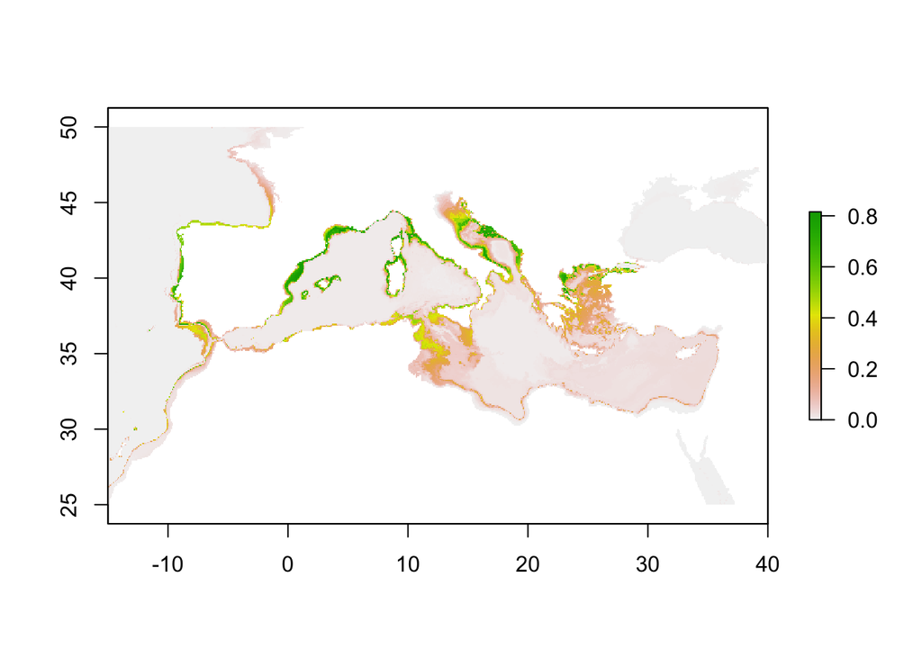

```r
# predict with Maxent to raster stack
map <- predict(model, environmentalConditions, type=c("logistic"))
plot(map)
```

```r
# determine the threshold maximazing the sum of sensitivity and specificity
threshold <- thresholdMaxTSS(model)
```

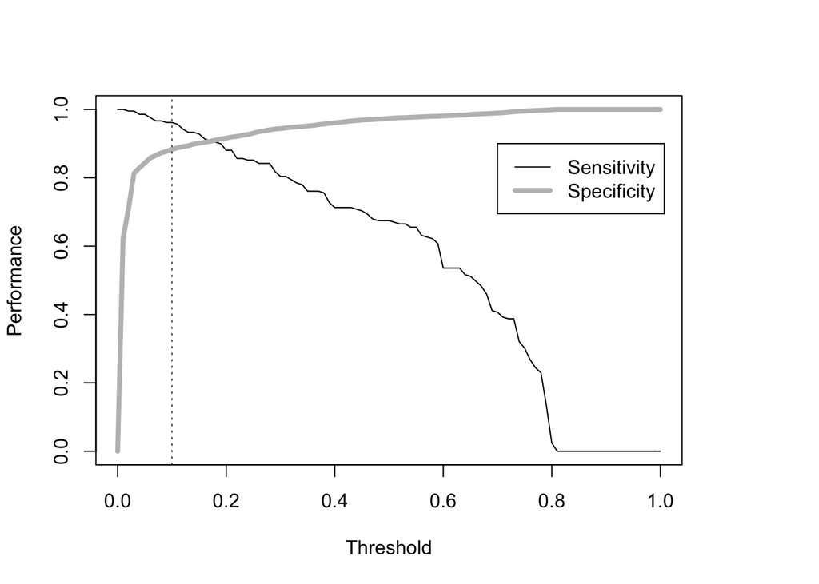

```r
threshold
```

```
## [1] 0.1
```

```r
# determine model performance
getAccuracy(model,threshold = threshold)
```

```
##   threshold omission.rate sensitivity specificity prop.correct     Kappa
## 1       0.1    0.03827751   0.9617225      0.8829    0.8845137 0.2267962
```

```r
getAUC(model, test = TRUE)
```

```
## [1] 0.9616861
```

```r
# generate a reclassification table
thresholdConditions <- data.frame(from = c(0,threshold) , to=c(threshold,1) , reclassValue=c(0,1))
thresholdConditions
```

```
##   from  to reclassValue
## 1  0.0 0.1            0
## 2  0.1 1.0            1
```

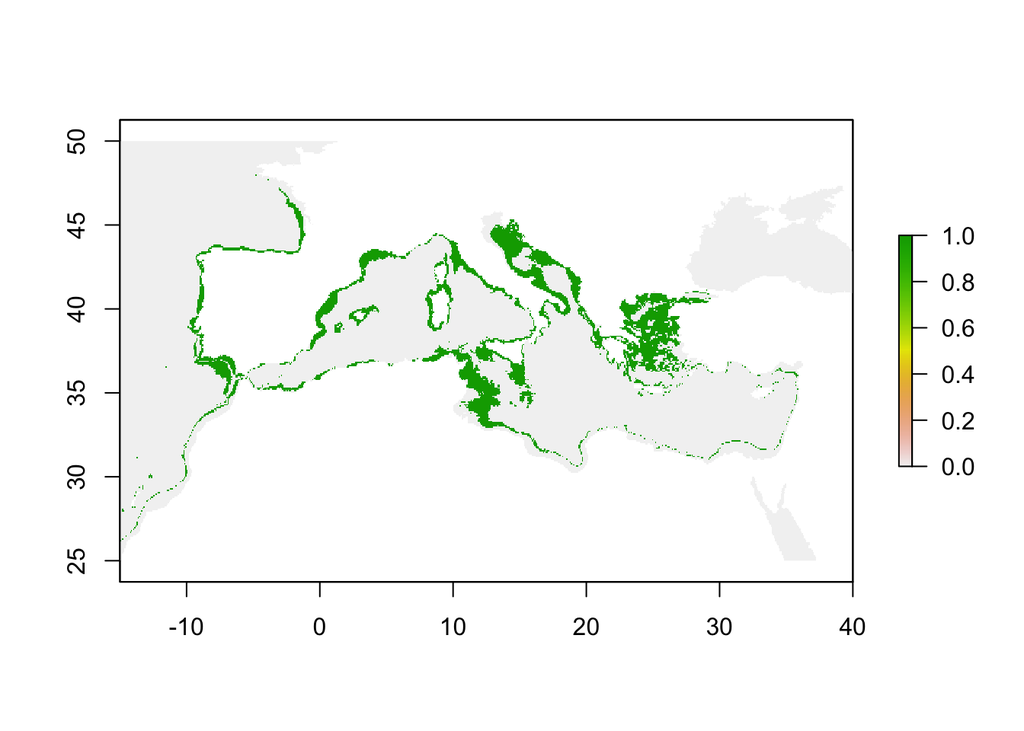

```r
# apply threshold to reclassify the predictive surface
map <- reclassify(map, rcl = thresholdConditions)
plot(map)
```

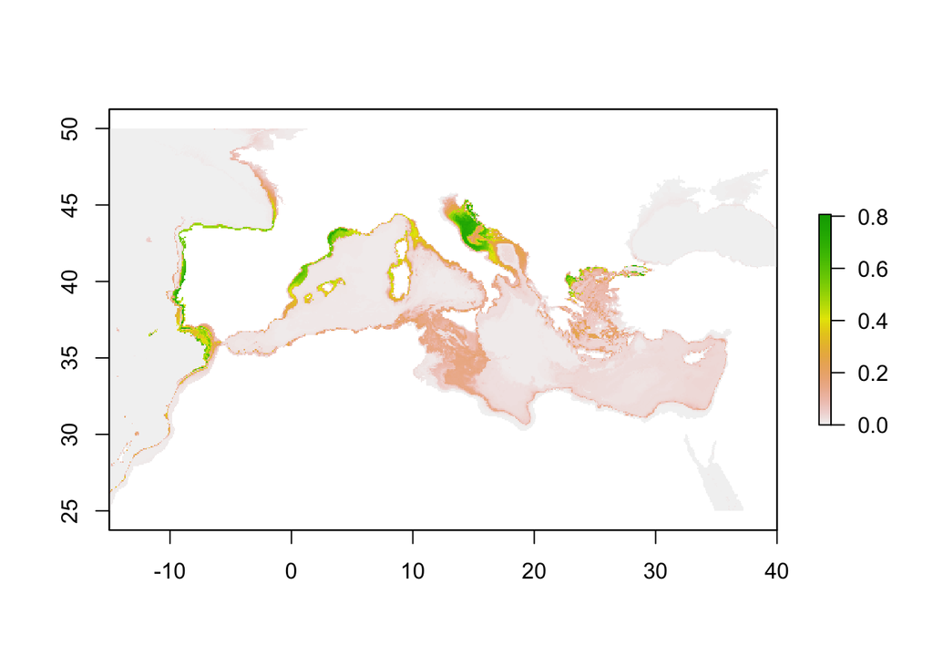

```r
# load layers of sea surface temperatures for the future
environmentalConditionsRCP26 <- load_layers(c("BO2_RCP26_2100_tempmin_bdmean","BO2_RCP26_2100_tempmax_bdmean"))

# change layer names for them to match
names(environmentalConditionsRCP26) <- c("BO2_tempmin_bdmean","BO2_tempmax_bdmean")

# crop layers to the European extent
environmentalConditionsRCP26 <- crop(environmentalConditionsRCP26,europeanExtent)

# predict with Maxent to raster stack
mapRCP26 <- predict(model, environmentalConditionsRCP26, type=c("logistic"))
plot(mapRCP26)
```

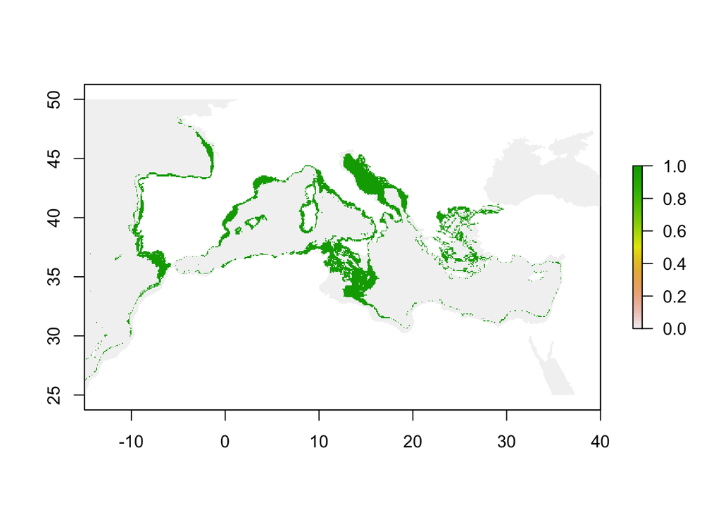

```r
# apply threshold to reclassify the future predictive surface
mapRCP26 <- reclassify(mapRCP26, rcl = thresholdConditions)
plot(mapRCP26)
```

###### Challenge 8.3

The main objetive of this challenge is to **fit** a MaxEnt model and **reclassify** a predictive surface (e.g., present) by using a threshold maximizing the sum of sensitivity and specificity.

```r
# packages, data and functions needed to accomplish the challenge
source("sourceFunctions.R")

list_layers(datasets = "Bio-ORACLE")
read.csv()
crop()
backgroundInformation()
prepareModelData()
get.block()
train()
thresholdMaxTSS()
predict()
data.frame()
reclassify()
plot()
```

##### Variable relative importance and response curves [!]

Inspecting variable relative importance and response curves to assess for ecological meaning in the models.

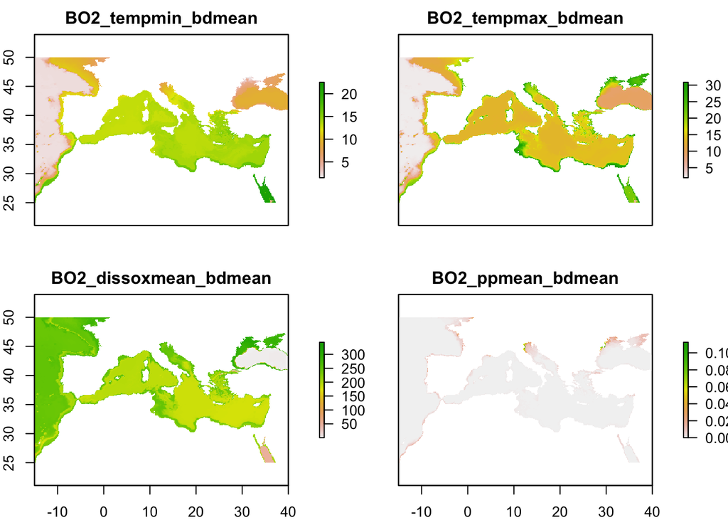

```r
# load a presence dataset for a deep coral
presences <- read.csv("Data/dataBases/Paramuricea_clavata.csv",sep=";")
presences <- presences[,c("Lon","Lat")]

# load layers of sea surface temperatures and nutrients
environmentalConditions <- load_layers(c("BO2_tempmin_bdmean","BO2_tempmax_bdmean","BO2_dissoxmean_bdmean","BO2_ppmean_bdmean"))

# crop layers to the European extent
europeanExtent <- extent(-15, 40, 25, 50)
environmentalConditions <- crop(environmentalConditions,europeanExtent)
plot(environmentalConditions)
```

```r
# generate pseudo-absences
background <- backgroundInformation(environmentalConditions,n=10000)

# extract environmental values and make a data.frame with PA information
modelData <- prepareModelData(presences,background,environmentalConditions)

# fit a Maxent model to the dataset
model <- train("Maxnet", modelData, folds = NULL )

# calculate the variable relative importance with permutations
viModel <- varImp(model, permut = 5)
viModel
```

```
##                Variable Permutation_importance    sd
## 1    BO2_tempmax_bdmean                   39.8 0.007
## 2    BO2_tempmin_bdmean                   34.3 0.018
## 3 BO2_dissoxmean_bdmean                   25.3 0.006
## 4     BO2_ppmean_bdmean                    0.6 0.001
```

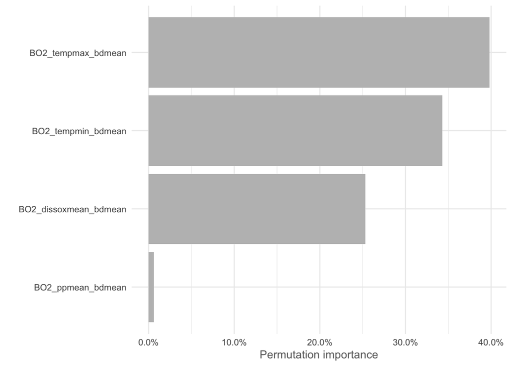

```r
plotVarImp(viModel)
```

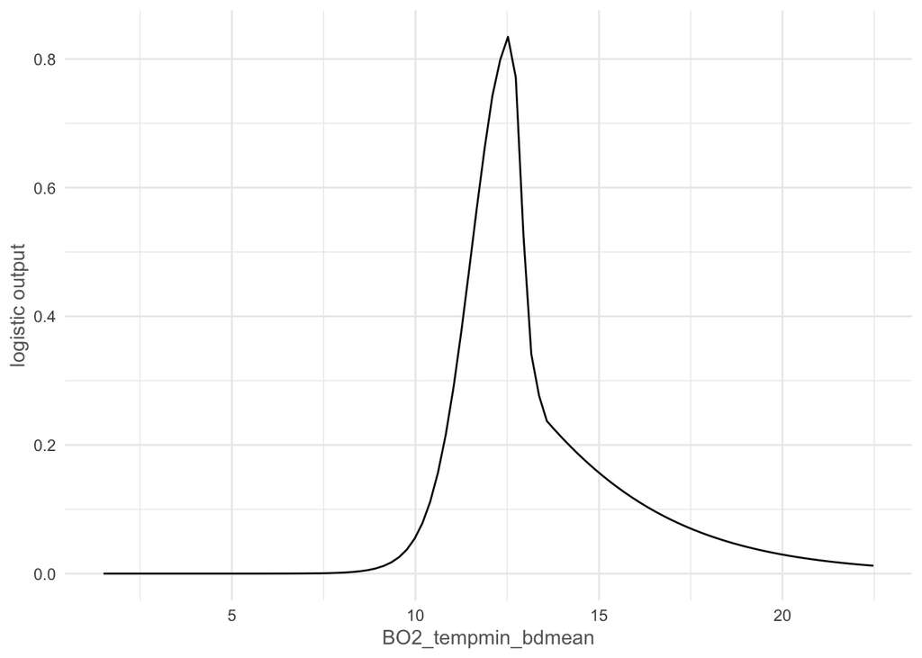

```r
# inspecting response curves
plotResponse(model, var = "BO2_tempmin_bdmean", type = "logistic", only_presence = FALSE, marginal = FALSE, rug = FALSE, color="Black")
```

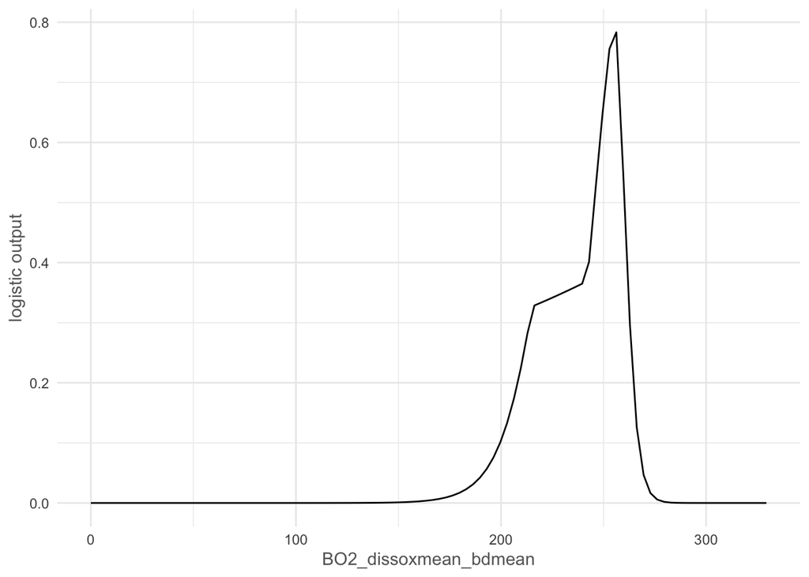

```r
plotResponse(model, var = "BO2_dissoxmean_bdmean", type = "logistic", only_presence = FALSE, marginal = FALSE, rug = FALSE, color="Black")
```

###### Challenge 8.4

The main objetive of this challenge is to **evaluate** a model by inspecting variable relative importance and response curves.

```r
# packages, data and functions needed to accomplish the challenge
source("sourceFunctions.R")

list_layers(datasets = "Bio-ORACLE")
read.csv()
crop()
backgroundInformation()
prepareModelData()
get.block()
train()
varImp()
plotVarImp()
plotResponse()
```

R Markdown tutorial developed by Jorge Assis under the International License [[CC BY 4.0]](https://creativecommons.org/licenses/by/4.0/). When using, copying or modifying, the attribution citation should be **Assis, J. (2020) Marine Ecological Modelling and Global Climate Change. theMarineDatasSientist**.